# NB07 — Behavioural-Diagnosis Synthetic Lab (centerpiece)

**RQ:** RQ2, RQ2.1, RQ2.2, RQ2.4 — can a neural network classify a student's behavioural scenario from response metadata, which metrics operationalise each trait, and are near-identical scores mapped to near-identical treatment plans?

**The honesty boundary (NB00).** The proxy dataset has NO response time, distractor choice, or cognitive-load field — every behavioural metric in the RQ note is uncomputable from real Noxed-proxy logs. This notebook does NOT pretend otherwise. It builds a parametrised SYNTHETIC generator for the 12 authored student cases, scaffolded on real item difficulty (NB01) so the synthetic sessions are at least grounded in a realistic difficulty distribution, then asks an honest feasibility question: **if** these metrics could be measured, would the 12 cases actually be separable, or do the RQ note's own confound caveats (impulsivity/anxiety/rapid-guessing entanglement) show up as real classifier confusion? The result is a feasibility study and a minimum-real-data specification, not a validated behavioural classifier.

```python
import os, sys
sys.path.insert(0, "/root/src" if os.path.exists("/root/src") else "../src")
import numpy as np
import pandas as pd
import matplotlib.pyplot as plt
import mlflow
from sklearn.decomposition import PCA
from sklearn.ensemble import RandomForestClassifier
from sklearn.model_selection import cross_val_predict, StratifiedKFold
from sklearn.metrics import f1_score, confusion_matrix
from sklearn.preprocessing import StandardScaler
import umap

from noxed import data, behavioural, tracking, paths

DATA_DIR = paths.data_dir(); OUT = paths.outcomes_dir(); FIG = paths.figures_dir()
rng = np.random.default_rng(42)
```

## 1. Ground the generator in real item-difficulty (NB01)

```python
difficulty_path = OUT / "question_difficulty.csv"
if difficulty_path.exists():
    D_sample = pd.read_csv(difficulty_path)["D_blend"].dropna().to_numpy()
    print(f"using {len(D_sample):,} real D_blend values from NB01")
else:
    qmeta = data.load_question_metadata(DATA_DIR)
    D_sample = qmeta.loc[qmeta["attempted"] > 0, "error_rate"].dropna().to_numpy()
    print(f"NB01 outcome not found -- falling back to {len(D_sample):,} raw error_rate values")
```

```
using 7,217 real D_blend values from NB01
```

## 2. Generate the synthetic population (all 12 cases + control)

```python
N_STUDENTS_PER_CASE = 120
N_ITEMS_PER_SESSION = 60
all_cases = behavioural.CASES + ["typical"]

sessions, metrics_rows = [], []
for case in all_cases:
    for s in range(N_STUDENTS_PER_CASE):
        session = behavioural.generate_synthetic_session(rng, case, D_sample, n_items=N_ITEMS_PER_SESSION)
        session["student_id"] = f"{case}_{s}"
        sessions.append(session)
        m = behavioural.compute_metrics(session)
        metrics_rows.append({"case": case, "student_id": f"{case}_{s}", **m})

metrics_df = pd.DataFrame(metrics_rows)
print(f"generated {len(all_cases)} cases x {N_STUDENTS_PER_CASE} students = {len(metrics_df)} synthetic sessions")
metrics_df.groupby("case").mean(numeric_only=True).round(3)
```

```
generated 13 cases x 120 students = 1560 synthetic sessions
```

| case | fast_error_rate | slow_correct_rate | timeout_rate | time_on_easy_share | carelessness | negation_error_gap | context_switch_cost | cognitive_load_sensitivity | end_of_match_decay | pressure_sensitivity | mean_tau | error_rate |
| --- | --- | --- | --- | --- | --- | --- | --- | --- | --- | --- | --- | --- |
| attention | 0.000 | 0.503 | 0.497 | 0.546 | 0.189 | 0.020 | 0.007 | 0.008 | 0.375 | -0.007 | 1.061 | 0.319 |
| cognitive_flexibility | 0.000 | 0.820 | 0.863 | 0.542 | 0.427 | -0.011 | 0.303 | 0.008 | 0.090 | -0.025 | 1.707 | 0.523 |
| impulsiveness | 0.818 | 0.000 | 0.000 | 0.540 | 0.569 | 0.005 | -0.023 | 0.011 | 0.002 | -0.003 | 0.225 | 0.648 |
| knowledge_absence | 0.000 | 0.494 | 0.495 | 0.547 | 0.751 | -0.015 | 0.002 | 0.005 | 0.020 | -0.008 | 1.060 | 0.793 |
| misconceptions | 0.000 | 0.500 | 0.500 | 0.539 | 0.579 | 0.008 | 0.016 | -0.002 | -0.023 | -0.010 | 1.063 | 0.646 |
| processing_speed | 0.000 | 0.815 | 0.855 | 0.544 | 0.375 | 0.008 | 0.004 | -0.013 | -0.000 | 0.007 | 0.977 | 0.482 |
| question_interpretation | 0.025 | 0.453 | 0.402 | 0.552 | 0.261 | 0.414 | -0.002 | 0.014 | 0.018 | 0.006 | 0.952 | 0.379 |
| rote_without_understanding | 0.000 | 0.498 | 0.503 | 0.551 | 0.159 | -0.010 | -0.028 | -0.009 | -0.015 | 0.001 | 1.067 | 0.366 |
| stress_overthinking | 0.000 | 0.532 | 0.571 | 0.544 | 0.228 | 0.012 | -0.017 | 0.014 | 0.043 | 0.430 | 1.211 | 0.355 |
| time_management_perfectionism | 0.000 | 0.813 | 0.768 | 0.755 | 0.167 | -0.007 | -0.017 | -0.018 | -0.025 | -0.021 | 1.977 | 0.294 |
| typical | 0.000 | 0.502 | 0.503 | 0.543 | 0.153 | -0.002 | -0.010 | -0.011 | -0.028 | 0.026 | 1.062 | 0.285 |
| weak_prior_knowledge | 0.000 | 0.908 | 0.907 | 0.553 | 0.496 | 0.013 | -0.004 | 0.005 | -0.008 | 0.005 | 1.675 | 0.578 |
| working_memory | 0.000 | 0.501 | 0.505 | 0.550 | 0.393 | 0.025 | -0.007 | 0.405 | -0.013 | 0.013 | 1.067 | 0.493 |

## 3. Trait separability: can a classifier recover the case from metrics alone?

```python
metric_cols = [c for c in metrics_df.columns if c not in ("case", "student_id")]
X = StandardScaler().fit_transform(metrics_df[metric_cols].fillna(0))
y = metrics_df["case"].to_numpy()

clf = RandomForestClassifier(n_estimators=300, max_depth=8, random_state=0)
cv = StratifiedKFold(n_splits=5, shuffle=True, random_state=0)
y_pred = cross_val_predict(clf, X, y, cv=cv)

per_class_f1 = pd.Series(f1_score(y, y_pred, average=None, labels=sorted(set(y))), index=sorted(set(y))).sort_values()
print("Per-case cross-validated F1 (RandomForest, 5-fold):")
print(per_class_f1.round(3))
print(f"\nmacro-F1: {f1_score(y, y_pred, average='macro'):.3f}")
```

```
Per-case cross-validated F1 (RandomForest, 5-fold):
rote_without_understanding       0.533
typical                          0.604
attention                        0.608
misconceptions                   0.745
working_memory                   0.787
knowledge_absence                0.854
weak_prior_knowledge             0.870
cognitive_flexibility            0.871
stress_overthinking              0.883
question_interpretation          0.922
processing_speed                 0.996
time_management_perfectionism    0.996
impulsiveness                    1.000
dtype: float64

macro-F1: 0.821
```

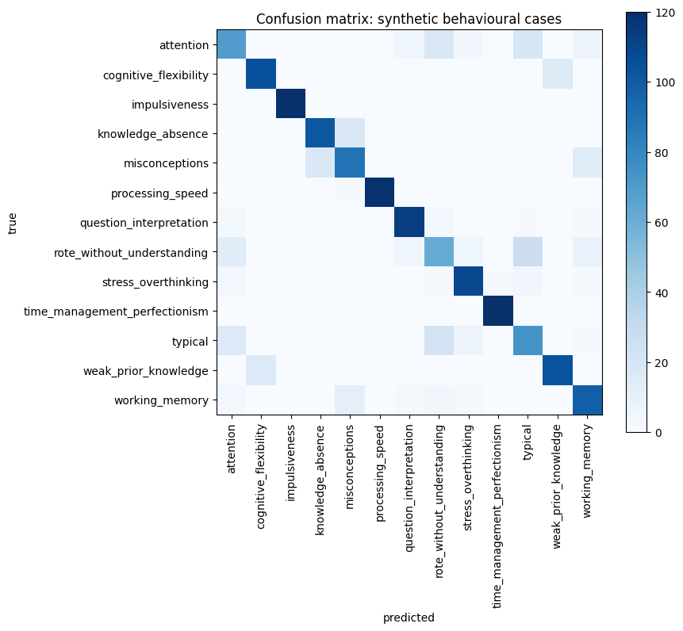

```python
cm = confusion_matrix(y, y_pred, labels=sorted(set(y)))
fig, ax = plt.subplots(figsize=(9, 8))
im = ax.imshow(cm, cmap="Blues")
ax.set_xticks(range(len(sorted(set(y))))); ax.set_xticklabels(sorted(set(y)), rotation=90)
ax.set_yticks(range(len(sorted(set(y))))); ax.set_yticklabels(sorted(set(y)))
ax.set_xlabel("predicted"); ax.set_ylabel("true")
ax.set_title("Confusion matrix: synthetic behavioural cases")
plt.colorbar(im)
plt.tight_layout()
fig.savefig(FIG / "07_confusion_matrix.png", dpi=120)
plt.show()
```

**Reading the confusion matrix.** Watch specifically for the confound the RQ note predicts: `impulsiveness` (fast + wrong) vs. any case with elevated fast-error patterns, and `stress_overthinking` vs. `weak_prior_knowledge` (both show elevated time + errors, differing only in WHEN they occur). If those specific pairs show elevated off-diagonal mass while well-separated pairs (e.g. `impulsiveness` vs. `time_management_perfectionism`, opposite-direction tau effects) stay clean, that is exactly the theoretically-predicted confound structure — a sign the simulation is behaving sensibly, not randomly.

## 4. Dimensionality reduction view (PCA + UMAP)

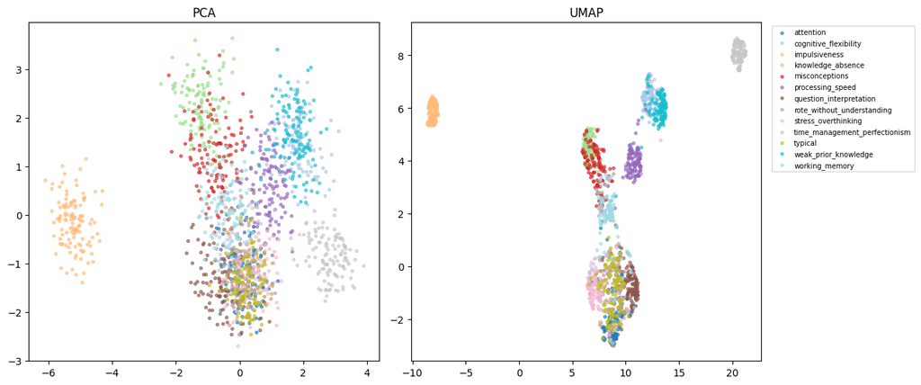

```python
pca = PCA(n_components=2).fit_transform(X)
reducer = umap.UMAP(n_components=2, random_state=0, n_neighbors=15)
emb = reducer.fit_transform(X)

fig, axes = plt.subplots(1, 2, figsize=(13, 5.5))
cases_list = sorted(set(y))
cmap = plt.get_cmap("tab20", len(cases_list))
for i, case in enumerate(cases_list):
    mask = y == case
    axes[0].scatter(pca[mask, 0], pca[mask, 1], s=8, alpha=0.6, color=cmap(i), label=case)
    axes[1].scatter(emb[mask, 0], emb[mask, 1], s=8, alpha=0.6, color=cmap(i), label=case)
axes[0].set_title("PCA"); axes[1].set_title("UMAP")
axes[1].legend(bbox_to_anchor=(1.02, 1), loc="upper left", fontsize=7)
plt.tight_layout()
fig.savefig(FIG / "07_embedding.png", dpi=120, bbox_inches="tight")
plt.show()
```

## 5. Score-to-plan smoothness (RQ2.4)

```
corr(score distance, plan distance) = 0.267  (positive & significant => nearby scores get nearby plans, as RQ2.4 requires)
```

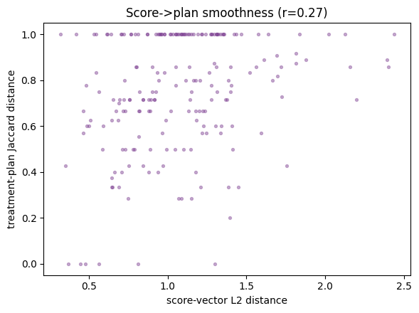

```python
thresholds = {
    "fast_error_rate": {"case": "impulsiveness", "cutoff": 0.4},
    "carelessness": {"case": "misconceptions", "cutoff": 0.3},
    "negation_error_gap": {"case": "question_interpretation", "cutoff": 0.15},
    "context_switch_cost": {"case": "cognitive_flexibility", "cutoff": 0.1},
    "cognitive_load_sensitivity": {"case": "working_memory", "cutoff": 0.1},
    "end_of_match_decay": {"case": "attention", "cutoff": 0.1},
    "pressure_sensitivity": {"case": "stress_overthinking", "cutoff": 0.1},
}

smoothness_rows = []
sample = metrics_df.sample(min(200, len(metrics_df)), random_state=0).reset_index(drop=True)
for i in range(len(sample) - 1):
    a, b = sample.iloc[i], sample.iloc[i + 1]
    scores_a = {k: a[k] for k in metric_cols}
    scores_b = {k: b[k] for k in metric_cols}
    plan_a = behavioural.score_to_plan(scores_a, thresholds)
    plan_b = behavioural.score_to_plan(scores_b, thresholds)
    smoothness_rows.append(behavioural.plan_smoothness(scores_a, scores_b, plan_a, plan_b))

smooth_df = pd.DataFrame(smoothness_rows)
corr_smoothness = smooth_df["score_l2_distance"].corr(smooth_df["plan_jaccard_distance"])
print(f"corr(score distance, plan distance) = {corr_smoothness:.3f}  "
      f"(positive & significant => nearby scores get nearby plans, as RQ2.4 requires)")

fig, ax = plt.subplots(figsize=(6, 4.5))
ax.scatter(smooth_df["score_l2_distance"], smooth_df["plan_jaccard_distance"], s=8, alpha=0.4, color="#7A3B8F")
ax.set_xlabel("score-vector L2 distance"); ax.set_ylabel("treatment-plan Jaccard distance")
ax.set_title(f"Score->plan smoothness (r={corr_smoothness:.2f})")
plt.tight_layout()
fig.savefig(FIG / "07_smoothness.png", dpi=120)
plt.show()
```

## 6. Save outcomes + minimum-real-data specification

```python
metrics_df.to_csv(OUT / "synthetic_behavioural_metrics.csv", index=False)
per_class_f1.reset_index().rename(columns={"index": "case", 0: "f1"}).to_csv(OUT / "trait_separability.csv", index=False)

worst_cases = per_class_f1.head(4)
print("Lowest-separability cases (highest priority for real instrumentation once Noxed's "
      "own game logs response time / distractor choice, per NB00):")
print(worst_cases)
```

```
Lowest-separability cases (highest priority for real instrumentation once Noxed's own game logs response time / distractor choice, per NB00):
rote_without_understanding    0.532751
typical                       0.604082
attention                     0.607930
misconceptions                0.744770
dtype: float64
```

```python
with tracking.start_run("07_behavioural_synthetic_lab", "behavioural", params={
    "n_cases": len(all_cases), "n_students_per_case": N_STUDENTS_PER_CASE, "n_items_per_session": N_ITEMS_PER_SESSION,
}):
    mlflow.log_metric("macro_f1", float(f1_score(y, y_pred, average="macro")))
    mlflow.log_metric("min_class_f1", float(per_class_f1.min()))
    mlflow.log_metric("smoothness_correlation", float(corr_smoothness))
    mlflow.log_artifact(str(OUT / "trait_separability.csv"))
    mlflow.log_artifact(str(FIG / "07_confusion_matrix.png"))
    mlflow.log_artifact(str(FIG / "07_embedding.png"))
print("logged to mlflow")
```

```
2026/07/12 02:22:10 INFO mlflow.tracking.fluent: Experiment with name 'noxed-behavioural' does not exist. Creating a new experiment.
```

[output not shown]

```
logged to mlflow
```

## Findings → consumed by

- `outcomes/trait_separability.csv` → **Behavioural NN** design: cases with low synthetic-F1 need EITHER additional real signal (response time / distractor choice — confirmed absent, NB00) or a merged/coarser class definition before a live model ships.
- `outcomes/synthetic_behavioural_metrics.csv` is a ready-made pre-training set for the NN's architecture search, standing in for real data during cold start (RQ5).
- The smoothness correlation is direct evidence for/against RQ2.4's design assumption.
- **Central caveat, restated:** every number in this notebook describes the SIMULATION's internal consistency, not real students. Treat it as a feasibility and instrumentation spec, not a validated classifier.